# Año de publicación

Universidad Central del Ecuador · FIGEMPA · Estadística y Probabilidades

Cristoffer Rumiguano, Ana Gabriela Fernández, Evelyn Bustamante, Jessica Haro y Jhonattan Ligña

2026-11-18

> Proyecto estrictamente académico. Variable cuantitativa discreta. Datos: EarthChem PetDB (CC BY 4.0), descargados el 13/10/2026. Web del proyecto: https://crisrumiguano-art.github.io/geoquimica-earthchem-ml/

## 1. Librerías

```r
library(gt)       # tablas con formato (Tabla Nro.)
library(dplyr)    # el operador %>% para encadenar pasos
library(e1071)    # asimetría y curtosis

# barplot(), pie(), plot(), boxplot(), legend() son del paquete graphics, y quantile(), sd(),
# var() del paquete stats: los dos vienen con R y se cargan solos, no necesitan library()
```

## 2. Leer datos

```r
# =========================
# Cargar datos
# =========================
# La primera vez descarga la base limpia del repositorio del proyecto (26 MB)
if (!file.exists("data/earthchem_limpio.csv.gz")) {
  dir.create("data", showWarnings = FALSE)
  download.file("https://github.com/crisrumiguano-art/geoquimica-earthchem-ml/raw/main/data/earthchem_limpio.csv.gz",
                "data/earthchem_limpio.csv.gz", mode = "wb")
}
base <- read.csv(gzfile("data/earthchem_limpio.csv.gz", encoding = "UTF-8"), check.names = FALSE)
dim(base)    # 159 760 porciones de roca y 75 variables
```

```
## [1] 159760     75
```

## 3. Selección de variable

Se toma la columna y se quitan los vacíos (vacío = no medido, nunca cero).

```r
x <- base[["Publication Year"]]
x <- x[!is.na(x)]                                      # quita vacíos
n <- length(x)
tipico <- x                                            # aquí se agrupan todos los datos
```

## 4. Tabla de distribución de frecuencia

El número de intervalos sale de la regla de Sturges, k = 1 + 3,3·log10(n), con una amplitud redonda para que los límites sean fáciles de leer.

```r
# =========================
# TABLA DE FRECUENCIAS
# =========================
k <- round(1 + 3.3 * log10(n))                         # número de intervalos
a <- (max(tipico) - min(tipico)) / k                   # amplitud calculada
a <- 10                                               # se redondea hacia arriba a un número cómodo
desde <- floor(min(tipico) / a) * a                    # primer límite: múltiplo de a
k <- floor((max(tipico) - desde) / a) + 1              # intervalos que hacen falta para llegar al máximo
Li <- desde + (0:(k - 1)) * a                          # límites inferiores
Ls <- Li + a                                           # límites superiores
MC <- (Li + Ls) / 2                                    # marca de clase

dentro <- x[x >= Li[1] & x <= Ls[k]]
ni <- as.vector(table(cut(dentro, breaks = c(Li, Ls[k]), right = FALSE, include.lowest = TRUE)))  # cuenta por intervalo [Li, Ls[
abajo <- sum(x < Li[1])                                # clase abierta "menor que" (outliers bajos)
arriba <- sum(x > Ls[k])                               # clase abierta "mayor o igual" (outliers altos)
hi <- round(ni / n * 100, 2)                           # frecuencia relativa (%)
todos <- c(abajo, ni, arriba)                          # con las clases abiertas, para acumular
cerradas <- 2:(k + 1)                                  # posiciones de los intervalos normales
Ni_asc <- cumsum(todos)[cerradas]                      # acumulada ascendente
Ni_dsc <- rev(cumsum(rev(todos)))[cerradas]            # acumulada descendente
Hi_asc <- round(cumsum(todos) / n * 100, 2)[cerradas]
Hi_dsc <- round(rev(cumsum(rev(todos))) / n * 100, 2)[cerradas]
TDF <- data.frame(Li, Ls, MC, ni, hi, Ni_asc, Ni_dsc, Hi_asc, Hi_dsc)
TDF_suma <- rbind(TDF, data.frame(Li = NA, Ls = NA, MC = NA, ni = sum(ni), hi = sum(hi),
                                   Ni_asc = NA, Ni_dsc = NA, Hi_asc = NA, Hi_dsc = NA))
TDF_suma$Li[k + 1] <- "TOTAL"
colnames(TDF_suma) <- c("Li", "Ls", "MC", "ni", "hi(%)", "Ni asc", "Ni desc", "Hi asc(%)", "Hi desc(%)")

TDF_suma %>%
  gt() %>%
  sub_missing(missing_text = "") %>%
  tab_header(
    title = md("*Tabla Nro. 1*"),
    subtitle = md("**Distribución de frecuencias de Año de publicación en las porciones de roca de EarthChem PetDB (1932-2025)**")
  ) %>%
  tab_source_note(source_note = md("Autores: Rumiguano, Fernández, Bustamante, Haro y Ligña · Datos: EarthChem PetDB (1932-2025)")) %>%
  tab_options(
    table.border.top.color = "black",
    table.border.bottom.color = "black",
    column_labels.border.top.color = "black",
    column_labels.border.bottom.color = "black",
    column_labels.border.bottom.width = px(2),
    row.striping.include_table_body = TRUE,
    heading.border.bottom.color = "black",
    heading.border.bottom.width = px(2),
    table_body.hlines.color = "gray"
  )
```

*Tabla Nro. 1*

**Distribución de frecuencias de Año de publicación en las porciones de roca de EarthChem PetDB (1932-2025)**

| Li | Ls | MC | ni | hi(%) | Ni asc | Ni desc | Hi asc(%) | Hi desc(%) |
| --- | --- | --- | --- | --- | --- | --- | --- | --- |
| 1930 | 1940 | 1935 | 12 | 0.01 | 12 | 159760 | 0.01 | 100.00 |
| 1940 | 1950 | 1945 | 9 | 0.01 | 21 | 159748 | 0.01 | 99.99 |
| 1950 | 1960 | 1955 | 73 | 0.05 | 94 | 159739 | 0.06 | 99.99 |
| 1960 | 1970 | 1965 | 1707 | 1.07 | 1801 | 159666 | 1.13 | 99.94 |
| 1970 | 1980 | 1975 | 13472 | 8.43 | 15273 | 157959 | 9.56 | 98.87 |
| 1980 | 1990 | 1985 | 24880 | 15.57 | 40153 | 144487 | 25.13 | 90.44 |
| 1990 | 2000 | 1995 | 27049 | 16.93 | 67202 | 119607 | 42.06 | 74.87 |
| 2000 | 2010 | 2005 | 35834 | 22.43 | 103036 | 92558 | 64.49 | 57.94 |
| 2010 | 2020 | 2015 | 38786 | 24.28 | 141822 | 56724 | 88.77 | 35.51 |
| 2020 | 2030 | 2025 | 17938 | 11.23 | 159760 | 17938 | 100.00 | 11.23 |
| TOTAL |  |  | 159760 | 100.01 |  |  |  |  |

Autores: Rumiguano, Fernández, Bustamante, Haro y Ligña · Datos: EarthChem PetDB (1932-2025)

```r
# Clases abiertas: datos fuera de los intervalos (no se borra ninguno)
c(menores = abajo, mayores = arriba)
```

```
## menores mayores
##       0       0
```

## 5. Gráficas

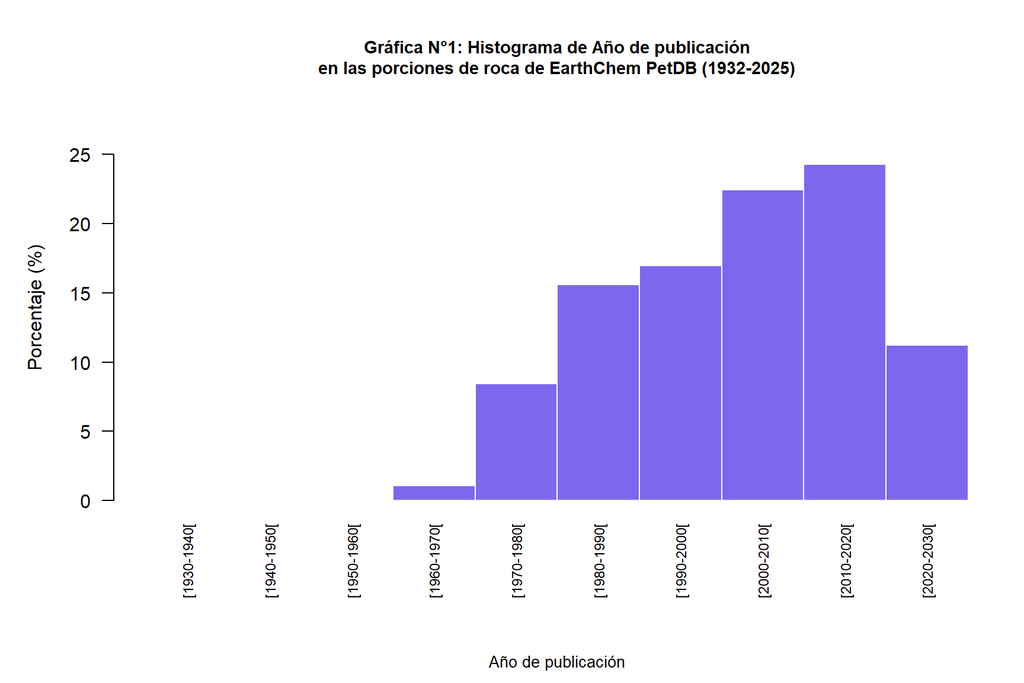

```r
# =========================
# HISTOGRAMA
# =========================
etiq <- paste0("[", Li, "-", Ls, "[")      # texto de cada intervalo
par(mar = c(8, 5, 5, 1))
barplot(hi,
        names.arg = etiq,
        space = 0,                          # barras juntas: la variable es continua
        main = "Gráfica N°1: Histograma de Año de publicación\nen las porciones de roca de EarthChem PetDB (1932-2025)",
        ylab = "Porcentaje (%)",
        col = "mediumslateblue",
        border = "white",
        ylim = c(0, max(hi) * 1.15),
        las = 2,
        cex.names = 0.75,
        cex.main = 0.9)
mtext("Año de publicación", side = 1, line = 6.5, cex = 0.85)
```

### 5.2 Polígono de frecuencias

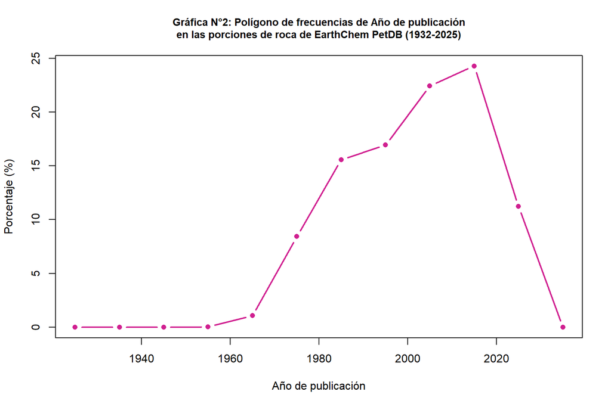

```r
# =========================
# POLÍGONO DE FRECUENCIAS
# =========================
plot(c(Li[1] - a / 2, MC, Ls[k] + a / 2), c(0, hi, 0),   # une las marcas de clase y cierra en cero
     type = "b",
     pch = 16,
     col = "violetred",
     lwd = 2,
     main = "Gráfica N°2: Polígono de frecuencias de Año de publicación\nen las porciones de roca de EarthChem PetDB (1932-2025)",
     xlab = "Año de publicación",
     ylab = "Porcentaje (%)",
     cex.main = 0.9)
```

### 5.3 Ojivas ascendente y descendente

Las dos ojivas se cruzan a la altura del 50 %: ahí está la mediana.

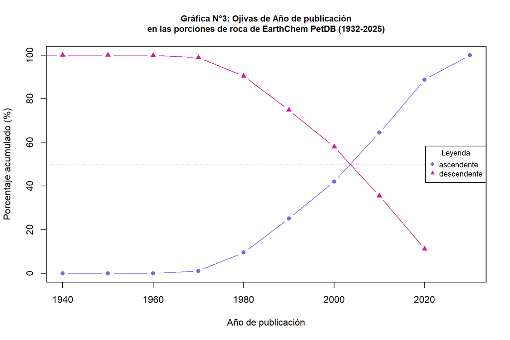

```r
# =========================
# OJIVAS
# =========================
plot(Ls, Hi_asc,
     type = "b",
     pch = 16,
     col = "mediumslateblue",
     ylim = c(0, 100),
     main = "Gráfica N°3: Ojivas de Año de publicación\nen las porciones de roca de EarthChem PetDB (1932-2025)",
     xlab = "Año de publicación",
     ylab = "Porcentaje acumulado (%)",
     cex.main = 0.9)
lines(Li, Hi_dsc, type = "b", pch = 17, col = "violetred")
abline(h = 50, lty = 3, col = "gray50")
legend("right",
       legend = c("ascendente", "descendente"),
       col = c("mediumslateblue", "violetred"),
       pch = c(16, 17),
       title = "Leyenda",
       cex = 0.8)
```

### 5.4 Diagrama de caja

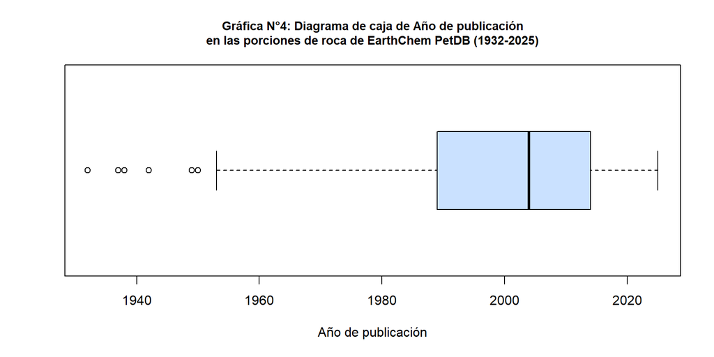

```r
# =========================
# DIAGRAMA DE CAJA
# =========================
boxplot(x,
        horizontal = TRUE,
        col = "lightsteelblue1",
        main = "Gráfica N°4: Diagrama de caja de Año de publicación\nen las porciones de roca de EarthChem PetDB (1932-2025)",
        xlab = "Año de publicación",
        cex.main = 0.9)
```

## 6. Indicadores estadísticos

Medidas de tendencia central, dispersión y forma, calculadas con los datos sin agrupar.

```r
# =========================
# INDICADORES ESTADÍSTICOS
# =========================
Mo <- as.numeric(names(which.max(table(x))))      # moda: el valor que más se repite
cuartiles <- quantile(x, c(0.25, 0.75), names = FALSE)
RI <- cuartiles[2] - cuartiles[1]                     # rango intercuartílico
atipicos <- sum(x < cuartiles[1] - 1.5 * RI | x > cuartiles[2] + 1.5 * RI)

tabla_indicadores <- data.frame(
  Variable = "Año de publicación",
  Rango = paste(round(min(x), 2), "a", round(max(x), 2)),
  X = round(mean(x), 2),
  Me = round(median(x), 2),
  Mo = round(Mo, 2),
  V = round(var(x), 2),
  Sd = round(sd(x), 2),
  Cv = paste0(round(sd(x) / mean(x) * 100, 2), " %"),
  As = round(skewness(x), 2),
  K = round(kurtosis(x), 2),
  Valores_Atipicos = atipicos
)

tabla_indicadores %>%
  gt() %>%
  sub_missing(missing_text = "") %>%
  tab_header(
    title = md("*Tabla Nro. 2*"),
    subtitle = md("**Indicadores estadísticos de Año de publicación en las porciones de roca de EarthChem PetDB (1932-2025)**")
  ) %>%
  tab_source_note(source_note = md("Autores: Rumiguano, Fernández, Bustamante, Haro y Ligña · Datos: EarthChem PetDB (1932-2025)")) %>%
  tab_options(
    table.border.top.color = "black",
    table.border.bottom.color = "black",
    column_labels.border.top.color = "black",
    column_labels.border.bottom.color = "black",
    column_labels.border.bottom.width = px(2),
    row.striping.include_table_body = TRUE,
    heading.border.bottom.color = "black",
    heading.border.bottom.width = px(2),
    table_body.hlines.color = "gray"
  )
```

*Tabla Nro. 2*

**Indicadores estadísticos de Año de publicación en las porciones de roca de EarthChem PetDB (1932-2025)**

| Variable | Rango | X | Me | Mo | V | Sd | Cv | As | K | Valores_Atipicos |
| --- | --- | --- | --- | --- | --- | --- | --- | --- | --- | --- |
| Año de publicación | 1932 a 2025 | 2001.24 | 2004 | 2015 | 226.92 | 15.06 | 0.75 % | -0.29 | -0.96 | 40 |

Autores: Rumiguano, Fernández, Bustamante, Haro y Ligña · Datos: EarthChem PetDB (1932-2025)

## 7. Conclusión

Se analizaron 159 760 porciones de roca con dato. La mediana es 2004, el coeficiente de variación es 0,75 % y la asimetría es -0,29 (cola hacia los valores bajos). Hay 40 valores atípicos según la regla intercuartílica; no se borran. La mayor parte de los datos es posterior a 1990: la producción creció con las técnicas modernas de laboratorio (ICP-MS). El año es discreto, pero se agrupa en intervalos porque toma muchos valores distintos.